# Metodos Estadisticos Avanzados - Reporte tecnico costos de venta empresas del sector construcción

Emilio Machado, Juan Jose Gonzalez, Juan David Perez, Sebastian Ospina

30/11/2020

# Analisis de las variables macro economicas con los costos de venta de las empresas del sector construcción

El objetivo general del trabajo es identificar los indicadores macroeconómicos o algunas de sus transformaciones que mejor describan el comportamiento de los costos de ventas de las empresas de algún sector.

*El dataset, y el codigo en R se puede encontrar en el siguiente repositorio en GitHub: https://github.com/seospinapo/MEA*

### Obtención de los datos desde las diferentes fuentes de información

La información que se tendrá en cuenta para el desarrollo del trabajo se obtendrá de la página web de la Superintendencia de Sociedades (https://siis.ia.supersociedades.gov.co/) en donde se hará uso de la opción de descarga masiva de estados para obtener la información de los estados de resultados para empresas plenas individuales al cierre de los años 2016, 2017, 2018 y 2019.

Para la selección del sector económico que se trabajó se analizaron la cantidad de empresas por cada uno y se decidió utilizar el segmento de la construcción que cuenta con 277 empresas únicas y es bastante relevante para el desarrollo económico del país pues contribuye en gran medida al producto interno bruto.

### Construcción de la base de datos

La información descargada se obtuvo en varios archivos, en dos de ellos se encontraban los estados financieros de cada empresa, uno con la información de 2016 y 2017 y otro con la información de 2018 y 2019. Los demás archivos contienen la información de los indicadores económicos y el procedimiento para unir todas las fuentes de información fue el siguiente: primero se tomaron los costos e ingresos de las empresas y se unificaron en una sola tabla. Posteriormente se extrajeron los datos de cada indicador al cierre del año y con ayuda de Excel se unieron a la información financiera de las empresas usando la columna de los años. Adicionalmente, se decidió agregar como variables adicionales las variaciones de los indicadores pues se considera que estas describen mejor el cambio en los costos de las empresas que el indicador como tal. Para el cálculo de estas variaciones fue necesario obtener los indicadores al cierre de 2015 y de igual forma en Excel se unieron a la tabla principal.

### Lectura de los datos

```r
datos<-read.csv("https://raw.githubusercontent.com/seospinapo/MEA/main/Base.csv",sep=";")
```

### Resumen de los datos

Como primer acercamiento a la data, evaluamos un resumen básico de los daos para obtener un conocimiento superficial y obtener un indicio de como iniciar el análisis exploratorio de la infroamción y el tratamiento a realizar sobre las variables con miras al desarrollo del modelo mencionado

```
##    ï..CIIU             Fecha                Mes          Nit
##  Length:814         Length:814         Min.   :12   Min.   :800010983
##  Class :character   Class :character   1st Qu.:12   1st Qu.:830090978
##  Mode  :character   Mode  :character   Median :12   Median :900221267
##                                        Mean   :12   Mean   :873282560
##                                        3rd Qu.:12   3rd Qu.:900514458
##                                        Max.   :12   Max.   :901170221
##  Ingresos_Ordinarios Costo_de_ventas         Anio      Tasa_desempleo
##  Min.   :0.000e+00   Length:814         Min.   :2016   Min.   :8.627
##  1st Qu.:1.067e+06   Class :character   1st Qu.:2017   1st Qu.:8.743
##  Median :8.083e+06   Mode  :character   Median :2018   Median :9.532
##  Mean   :4.278e+08                      Mean   :2018   Mean   :9.205
##  3rd Qu.:3.649e+07                      3rd Qu.:2019   3rd Qu.:9.721
##  Max.   :1.936e+11                      Max.   :2019   Max.   :9.721
##  Var_Tasa_desempleo Indice_Precios_Vivienda_Nueva
##  Min.   :-0.18934   Min.   :168.4
##  1st Qu.:-0.18934   1st Qu.:171.7
##  Median : 0.01924   Median :174.6
##  Mean   : 0.25858   Mean   :172.9
##  3rd Qu.: 1.09370   3rd Qu.:175.7
##  Max.   : 1.09370   Max.   :175.7
##  Var_Indice_Precios_Vivienda_Nueva Indice_Real_Precios_Vivienda_Usada
##  Min.   :0.006188                  Min.   :132.0
##  1st Qu.:0.006188                  1st Qu.:134.9
##  Median :0.014497                  Median :139.5
##  Mean   :0.013517                  Mean   :138.0
##  3rd Qu.:0.016753                  3rd Qu.:143.8
##  Max.   :0.019852                  Max.   :143.8
##  Var_Indice_Real_Precios_Vivienda_Usada   Inflacion     Variacion_PIB_Real
##  Min.   :0.02166                        Min.   :3.180   Min.   :1.359
##  1st Qu.:0.03088                        1st Qu.:3.180   1st Qu.:2.087
##  Median :0.03264                        Median :3.800   Median :2.515
##  Mean   :0.03289                        Mean   :4.129   Mean   :2.384
##  3rd Qu.:0.03441                        3rd Qu.:4.090   3rd Qu.:3.322
##  Max.   :0.04471                        Max.   :5.750   Max.   :3.322
##  Salario_Minimo   Var_Salario_Minimo      TRM          Var_TRM
##  Min.   :689455   Min.   :5.90       Min.   :2984   Min.   :-0.047233
##  1st Qu.:737717   1st Qu.:5.90       1st Qu.:3001   1st Qu.:-0.005569
##  Median :781242   Median :6.00       Median :3250   Median : 0.008428
##  Mean   :763945   Mean   :6.42       Mean   :3142   Mean   : 0.015141
##  3rd Qu.:828116   3rd Qu.:7.00       3rd Qu.:3277   3rd Qu.: 0.089058
##  Max.   :828116   Max.   :7.00       Max.   :3277   Max.   : 0.089058
##       UVR           Var_UVR         Var_IPP           Var_ICCV
##  Min.   :242.5   Min.   :3.280   Min.   :0.01615   Min.   :2.490
##  1st Qu.:252.4   1st Qu.:3.280   1st Qu.:0.01859   1st Qu.:2.490
##  Median :260.7   Median :3.850   Median :0.03086   Median :2.840
##  Mean   :257.5   Mean   :4.274   Mean   :0.02918   Mean   :3.246
##  3rd Qu.:270.7   3rd Qu.:4.090   3rd Qu.:0.04662   3rd Qu.:3.160
##  Max.   :270.7   Max.   :6.210   Max.   :0.04662   Max.   :4.770
##     Var_FIVI
##  Min.   :3.200
##  1st Qu.:3.200
##  Median :6.900
##  Mean   :6.571
##  3rd Qu.:8.600
##  Max.   :9.600
```

Como premisa y criterio de exclusión para el análisis que se va a llevar a cabo, unicamente se realizará el tratamiento para las empreaas cuyos costos e ingresos de venta sean superiores a cero, pues como proposito fundamental de trabajo, se buscrá predicir costos de vente para empresas en fase totalmente operativa y no sobre empresas que se encuentren inactivas o en etapa preoperativa

### Acotación de los datos

```r
datos<-datos[datos$Costo_de_ventas>0, ]
datos<-datos[datos$Ingresos_Ordinarios>0, ]
```

Debido a que algunas variables de variación se encuentran en unidades de porcentaje, se llevan las variaciones de estas a la misma unidad de los otros indicadores, con el proposito de unificar la data. Se calculan variaciones de los indicadores mcroeconomicos, pues se considera que un dato puntual no logra describir la relación que hay con los costos de venta, ya que las variaciones de estas cifras son las que llevan a generar cambios en las cifras financieras de las empresas.

### Creación de nuevas variables

```r
datos['Inflacion']=as.numeric(datos$Inflacion)/100
datos['Variacion_PIB_Real']=as.numeric(datos$Variacion_PIB_Real)/100
datos['Var_Salario_Minimo']=as.numeric(datos$Var_Salario_Minimo)/100
datos['Var_UVR']=as.numeric(datos$Var_UVR)/100
datos['Var_ICCV']=as.numeric(datos$Var_ICCV)/100
datos['Var_FIVI']=as.numeric(datos$Var_FIVI)/100
```

### Creación de las variables respuesta

La variable objetivo del analisis es el costo de venta, pero debido a que existen empresas de diferentes tamaños en ventas, se hace necesario disminuir la variabilidad que se pueda generar por esta, en donde se estandarice y se lleve a cifras comparables, por esto se llevan cada una de las siguientes transformaciones: Dividir los costos de venta por los ingresos generados, lo que genera una eliminación de la variabilidad

```r
datos['prop_costos']=as.numeric(datos$Costo_de_ventas)/as.numeric(datos$Ingresos_Ordinarios)
```

Una segunda variable respuesta, es la indexación de los costos de venta a valor presente, para que estos sean comparables dentro del mismo modelo y observados en un mismo periodo de tiempo

```r
for(i in 1:nrow(datos)){
  if (datos[i,"Anio"]==2016) {
    datos[i,"costoindex"]<-as.numeric(datos[i, "Costo_de_ventas"])*(1+0.0409)*(1+0.0318)*(1+0.0380)
  } else if (datos[i,"Anio"]==2017) {
    datos[i,"costoindex"]<-as.numeric(datos[i, "Costo_de_ventas"])*(1+0.0318)*(1+0.0380)
  } else if (datos[i,"Anio"]==2018) {
    datos[i,"costoindex"]<-as.numeric(datos[i, "Costo_de_ventas"])*(1+0.0380)
  } else {
    datos[i,"costoindex"]<-as.numeric(datos[i, "Costo_de_ventas"])*1
  }
}
```

## Analisis exploratorio de datos

### Analisis mediante boxplot

Como primer acercamiento al entendimiento de los datos, se realiza un Boxplot de la variable respuesta

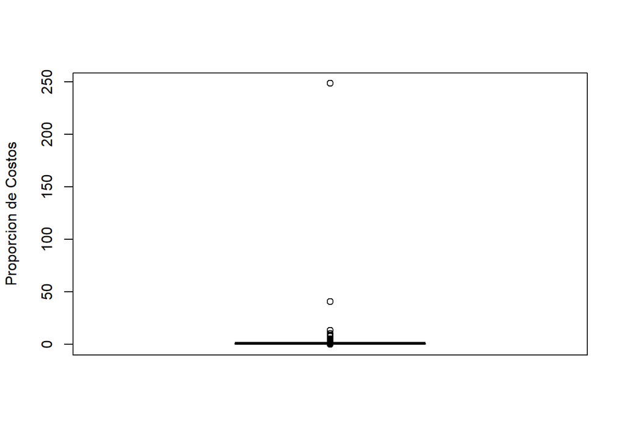

Se puede observar que hay algunos valores muy extremos y por lo tanto no se puede ver con claridad como esta distribuidos la mayoría de los registros. Para solucionar esto tomaremos unicamente la empresas cuya proporción de costos sobre ingresos sea menor a 1, es decir que sea una empresa rentable, es decir el margen bruto minimo de la empresa sea 0.

```r
datos2<-datos[datos$prop_costos<1, ]
```

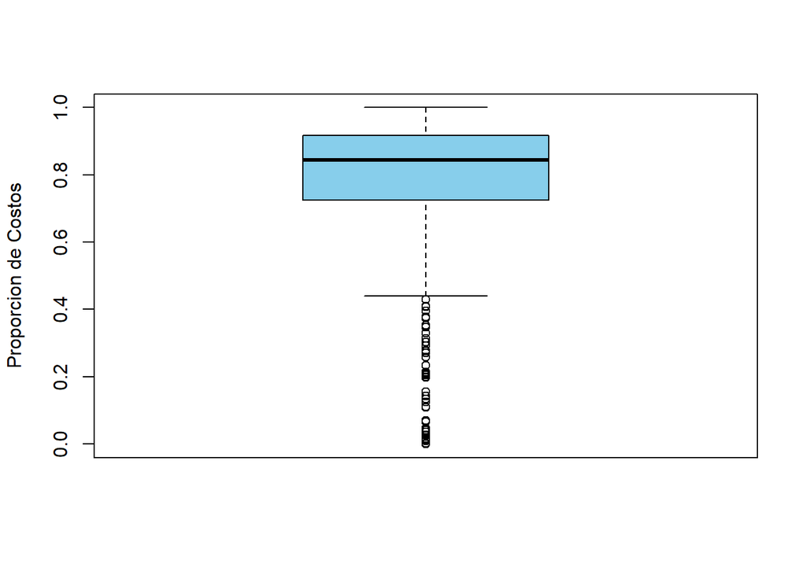

Se puede observar que la mayoría de las empresas tienen una proporción entre 0.6 y 1, aunque hay varias con una proporción menor a 0.5. Para analizar la distribución de esta variable a continuación se graficará el histograma

### Analisis por medio de histogramas

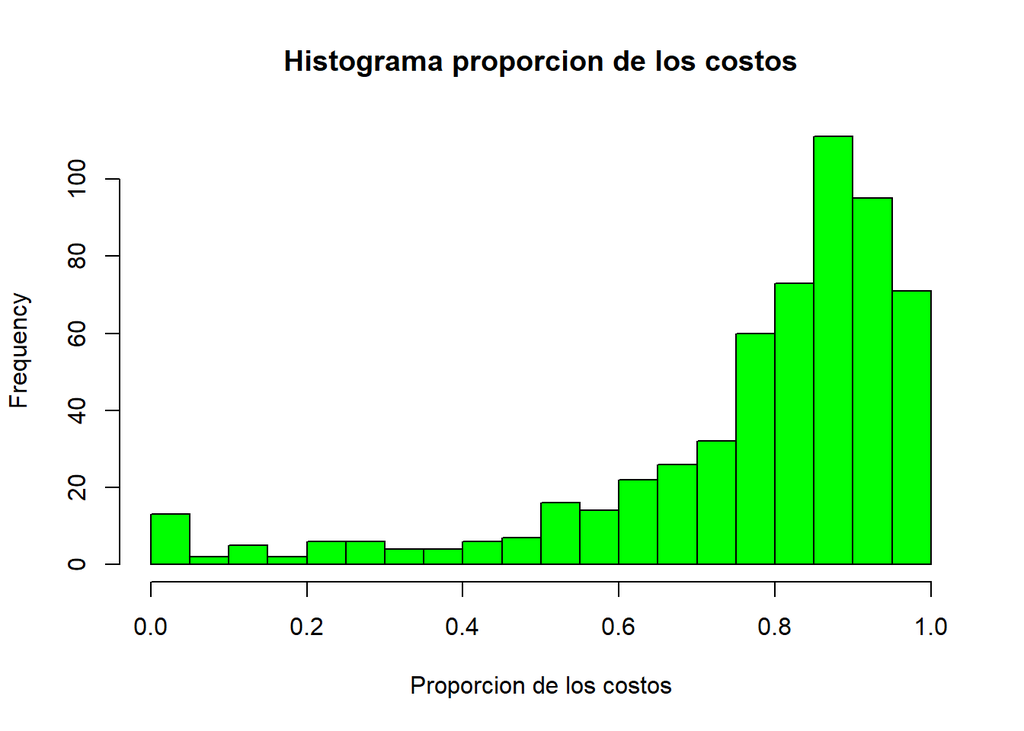

Se puede observar que la mayoria de empresas tienen una proporción superior a 0.5 con mayor concentración en el rango [0.8-1.0], por lo que se van a considerar solo las empresas cuya proporción sea >=0.5 y <=1.2. Esto implica tener empresas cuyo margen bruto es negativo, buscando que la variable respuesta se aproxime a una distribución normal.

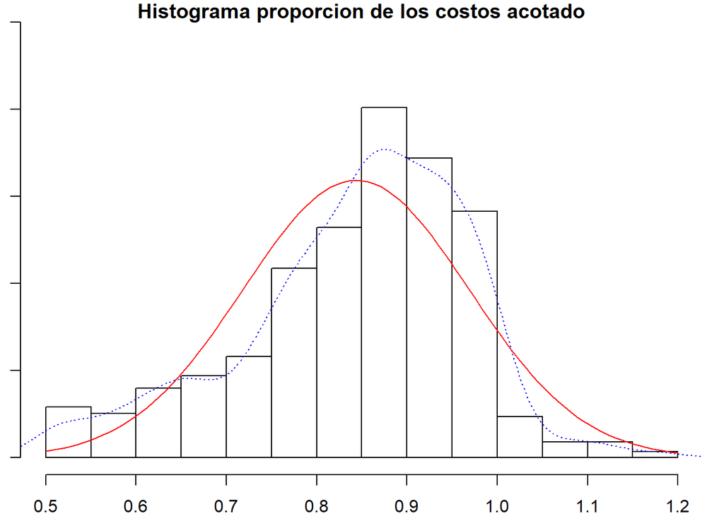

Se puede observar en el histograma que la variable respuesta se aproxima a una distribución normal.

Se procede a eliminar las variables que inicialmente no se van a utilizar dentro de la construcción del modelo ya que en algunos casos se van a utilizar son sus variaciones.

Adicional a la eliminación de las variables que no se van a utilizar, se decide eliminar las empresas cuyos registros no aparezcan en los 4 años, ya que esto puede generar inconsistencias cuando se corra el modelo de efectos mixtos.

Una vez realida la limpieza de los datos, se procede a volver a generar el histograma de frecuencias la proporcion de los cotos, y del logaritmo de los costos indexados. Se decidió mirar esta segunda variable respuesta, buscando un mejor ajuste a la distribución normal.

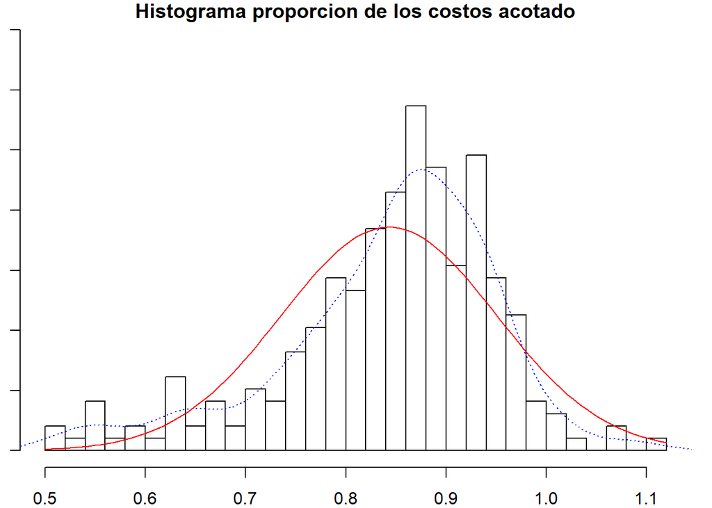

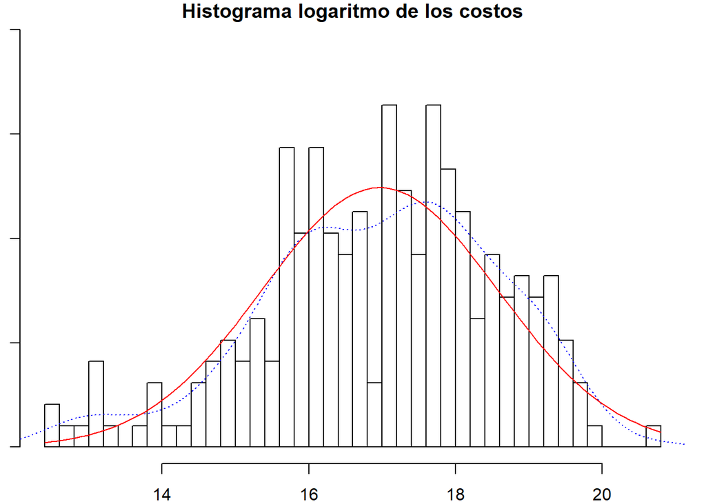

Se puede observar el logaritmo natural de los costos indexados presenta una distribución mas cercana a la distribución normal, sin mebargo, se continuará haciendo el análisis con la proporción de los costos ya que también cuenta con un ajuste aceptable y al usalra se esta eliminando la variabilidad proveniente del tamaño de las empresas.

### Analisis de correlaciones

Posteriormente se hace un analisis de correlación entre las variables, para identificar cuales variables podrían generar inconsistencias en la construcción del modelo por ser muy correlacionadas entre si

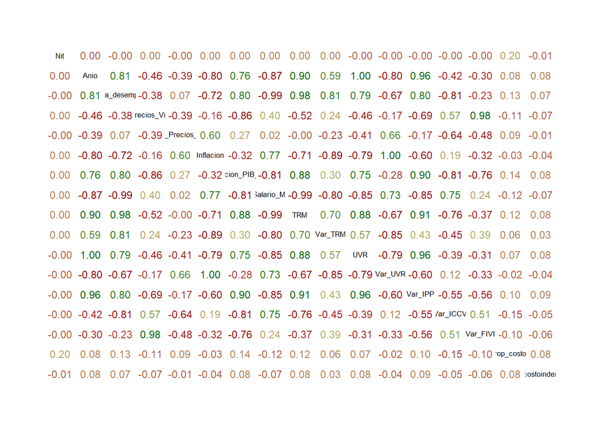

Al realizar este analisis se observa que ninguna variable tiene alta correlación lineal con la variable respuesta, ya que la estructura de datos analizada compara 552 observaciones con 4 observaciones de los indicadores macroeconómicos, lo que no permite un buen analisis de la correlación, por lo que se decide realizar el analisis de correlación con el promedio de la variable respuesta y de esta forma poder caracterizar la correlación con un estadístico que describa el comportamiento de medida central

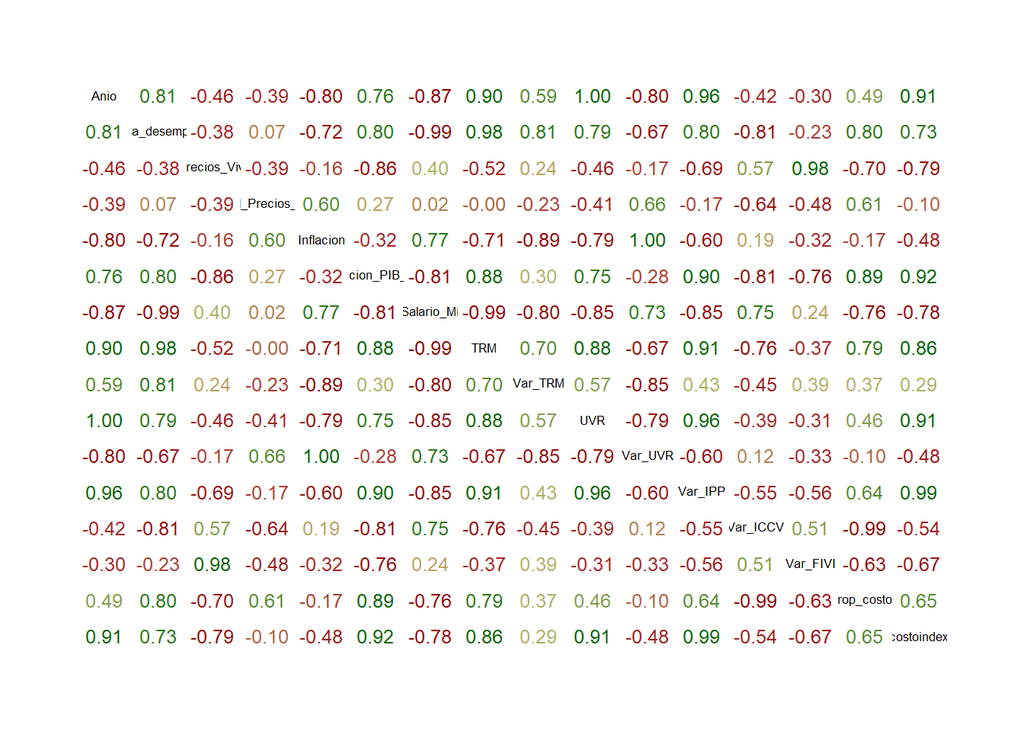

### Analisis de boxplot entre variables

Para obtener una representación visual de esta relación se graficarán lo boxplot de las variables con mayor correlación con la variable respuesta.

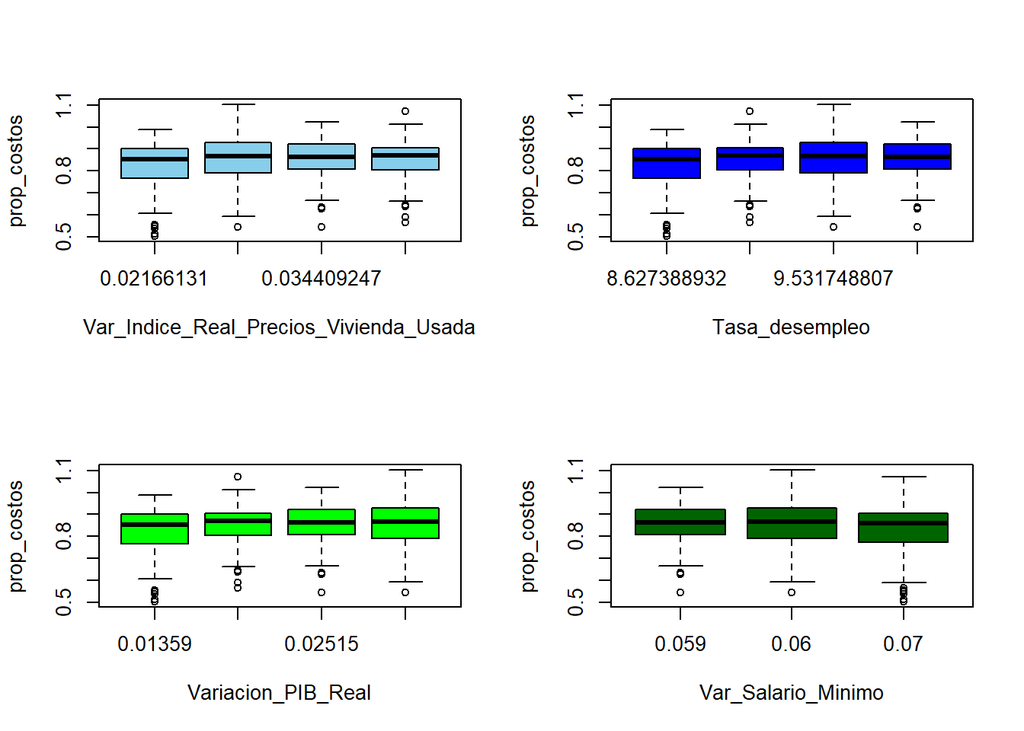

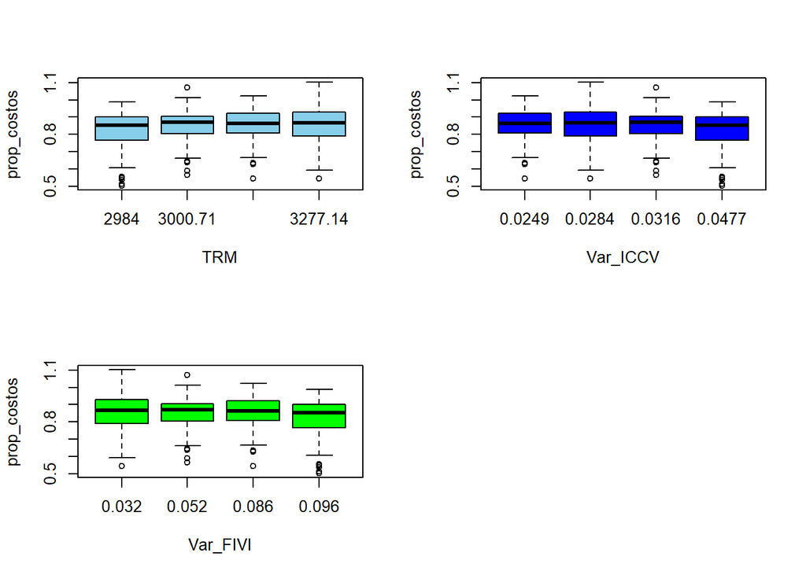

## Construcción de modelos

Posteriormente, se separá pa muestra en entrenamiento y prueba con el fin de tener datos para probar el desempeño del modelo más adelante, se fija una semilla para que siempre se obtenga la misma muestra de entrenamiento y prueba aleatoria, y se define un tamaño 70-30 para entrenamiento y prueba respectivamente

### Modelos por regresión lineal

Incialmente se hará una regresión lineal con el fin de identificar cuales son las variables que verdaderamente describen el comportamiento de los costos. Esta regresión se hará unicamente con las variables identificadas con alta correlacióncon la variable respuesta y que en lo posible no tengan alta colinealidad entre ellas mismas.

```r
modelo3<-lm(prop_costos ~ Var_ICCV+  Variacion_PIB_Real + Tasa_desempleo  + Var_Indice_Precios_Vivienda_Nueva + Var_Salario_Minimo + TRM  + Var_FIVI
                 , data=datos_entrenamiento)
summary(modelo3)
```

```
##
## Call:
## lm(formula = prop_costos ~ Var_ICCV + Variacion_PIB_Real + Tasa_desempleo +
##     Var_Indice_Precios_Vivienda_Nueva + Var_Salario_Minimo +
##     TRM + Var_FIVI, data = datos_entrenamiento)
##
## Residuals:
##      Min       1Q   Median       3Q      Max
## -0.32406 -0.04159  0.01437  0.06573  0.23612
##
## Coefficients: (4 not defined because of singularities)
##                                   Estimate Std. Error t value Pr(>|t|)
## (Intercept)                        0.70886    0.30447   2.328   0.0211 *
## Var_ICCV                          -0.57748    1.71245  -0.337   0.7364
## Variacion_PIB_Real                 1.80491    2.07509   0.870   0.3857
## Tasa_desempleo                     0.01193    0.03123   0.382   0.7030
## Var_Indice_Precios_Vivienda_Nueva       NA         NA      NA       NA
## Var_Salario_Minimo                      NA         NA      NA       NA
## TRM                                     NA         NA      NA       NA
## Var_FIVI                                NA         NA      NA       NA
## ---
## Signif. codes:  0 '***' 0.001 '**' 0.01 '*' 0.05 '.' 0.1 ' ' 1
##
## Residual standard error: 0.1018 on 164 degrees of freedom
## Multiple R-squared:  0.0462, Adjusted R-squared:  0.02875
## F-statistic: 2.648 on 3 and 164 DF,  p-value: 0.05077
```

```r
summary(datos_entrenamiento["prop_costos"])
```

```
##   prop_costos
##  Min.   :0.5016
##  1st Qu.:0.8001
##  Median :0.8616
##  Mean   :0.8408
##  3rd Qu.:0.9065
##  Max.   :1.1022
```

Con el fin de identificar las variables regresoras que verdaderamente aportan información relevante se corrió un proceso backward donde se evaluen las posibles combinaciones de regresores y se vayan eliminando aquellos que no sean significativos.

```r
step(object = modelo3, direction = "both", trace = 1)
```

```
## Start:  AIC=-763.58
## prop_costos ~ Var_ICCV + Variacion_PIB_Real + Tasa_desempleo +
##     Var_Indice_Precios_Vivienda_Nueva + Var_Salario_Minimo +
##     TRM + Var_FIVI
##
##
## Step:  AIC=-763.58
## prop_costos ~ Var_ICCV + Variacion_PIB_Real + Tasa_desempleo +
##     Var_Indice_Precios_Vivienda_Nueva + Var_Salario_Minimo +
##     TRM
##
##
## Step:  AIC=-763.58
## prop_costos ~ Var_ICCV + Variacion_PIB_Real + Tasa_desempleo +
##     Var_Indice_Precios_Vivienda_Nueva + Var_Salario_Minimo
##
##
## Step:  AIC=-763.58
## prop_costos ~ Var_ICCV + Variacion_PIB_Real + Tasa_desempleo +
##     Var_Indice_Precios_Vivienda_Nueva
##
##
## Step:  AIC=-763.58
## prop_costos ~ Var_ICCV + Variacion_PIB_Real + Tasa_desempleo
##
##                      Df Sum of Sq    RSS     AIC
## - Var_ICCV            1 0.0011795 1.7022 -765.47
## - Tasa_desempleo      1 0.0015134 1.7025 -765.44
## - Variacion_PIB_Real  1 0.0078467 1.7088 -764.81
## <none>                            1.7010 -763.58
##
## Step:  AIC=-765.47
## prop_costos ~ Variacion_PIB_Real + Tasa_desempleo
##
##                                     Df Sum of Sq    RSS     AIC
## - Tasa_desempleo                     1 0.0038016 1.7060 -767.09
## - Variacion_PIB_Real                 1 0.0133860 1.7155 -766.15
## <none>                                           1.7022 -765.47
## + Var_Indice_Precios_Vivienda_Nueva  1 0.0011795 1.7010 -763.58
## + Var_Salario_Minimo                 1 0.0011795 1.7010 -763.58
## + Var_FIVI                           1 0.0011795 1.7010 -763.58
## + TRM                                1 0.0011795 1.7010 -763.58
## + Var_ICCV                           1 0.0011795 1.7010 -763.58
##
## Step:  AIC=-767.09
## prop_costos ~ Variacion_PIB_Real
##
##                                     Df Sum of Sq    RSS     AIC
## <none>                                           1.7060 -767.09
## + Tasa_desempleo                     1  0.003802 1.7022 -765.47
## + Var_ICCV                           1  0.003468 1.7025 -765.44
## + Var_Indice_Precios_Vivienda_Nueva  1  0.003459 1.7025 -765.43
## + Var_Salario_Minimo                 1  0.002918 1.7030 -765.38
## + Var_FIVI                           1  0.002903 1.7030 -765.38
## + TRM                                1  0.002372 1.7036 -765.33
## - Variacion_PIB_Real                 1  0.077409 1.7834 -761.64
```

```
##
## Call:
## lm(formula = prop_costos ~ Variacion_PIB_Real, data = datos_entrenamiento)
##
## Coefficients:
##        (Intercept)  Variacion_PIB_Real
##             0.7707              3.0207
```

Otra conclusión que se pede observar del proceso anterior es que el modelo lineal estima coeficientes unicamente cuando se ingresan 3 regresores o menos. Esto se debe a que entre ellos existe alta colinealidad.

#### Modelos regresion lineal simple

```r
#Tasa de desempleo
modelo5<-lm(prop_costos ~ Tasa_desempleo, data=datos_entrenamiento)
summary(modelo5)
```

```
##
## Call:
## lm(formula = prop_costos ~ Tasa_desempleo, data = datos_entrenamiento)
##
## Residuals:
##      Min       1Q   Median       3Q      Max
## -0.31968 -0.04730  0.01610  0.06759  0.24559
##
## Coefficients:
##                Estimate Std. Error t value Pr(>|t|)
## (Intercept)     0.45528    0.15070   3.021  0.00292 **
## Tasa_desempleo  0.04211    0.01644   2.562  0.01130 *
## ---
## Signif. codes:  0 '***' 0.001 '**' 0.01 '*' 0.05 '.' 0.1 ' ' 1
##
## Residual standard error: 0.1017 on 166 degrees of freedom
## Multiple R-squared:  0.03803,    Adjusted R-squared:  0.03224
## F-statistic: 6.563 on 1 and 166 DF,  p-value: 0.0113
```

```r
AIC(modelo5)
```

```
## [1] -287.3888
```

```r
#Indice de precios de la vivienda nueva
modelo5<-lm(prop_costos ~ Var_Indice_Precios_Vivienda_Nueva, data=datos_entrenamiento)
summary(modelo5)
```

```
##
## Call:
## lm(formula = prop_costos ~ Var_Indice_Precios_Vivienda_Nueva,
##     data = datos_entrenamiento)
##
## Residuals:
##      Min       1Q   Median       3Q      Max
## -0.32236 -0.04030  0.02745  0.06129  0.23783
##
## Coefficients:
##                                   Estimate Std. Error t value Pr(>|t|)
## (Intercept)                        0.88371    0.02257  39.154   <2e-16 ***
## Var_Indice_Precios_Vivienda_Nueva -3.11661    1.53667  -2.028   0.0441 *
## ---
## Signif. codes:  0 '***' 0.001 '**' 0.01 '*' 0.05 '.' 0.1 ' ' 1
##
## Residual standard error: 0.1024 on 166 degrees of freedom
## Multiple R-squared:  0.02418,    Adjusted R-squared:  0.0183
## F-statistic: 4.113 on 1 and 166 DF,  p-value: 0.04414
```

```r
AIC(modelo5)
```

```
## [1] -284.9871
```

```r
#Indice de precios de la vivienda Usada
modelo5<-lm(prop_costos ~ Var_Indice_Real_Precios_Vivienda_Usada, data=datos_entrenamiento)
summary(modelo5)
```

```
##
## Call:
## lm(formula = prop_costos ~ Var_Indice_Real_Precios_Vivienda_Usada,
##     data = datos_entrenamiento)
##
## Residuals:
##      Min       1Q   Median       3Q      Max
## -0.32951 -0.04303  0.02274  0.06687  0.26318
##
## Coefficients:
##                                        Estimate Std. Error t value Pr(>|t|)
## (Intercept)                             0.81246    0.03282  24.753   <2e-16 ***
## Var_Indice_Real_Precios_Vivienda_Usada  0.86182    0.96731   0.891    0.374
## ---
## Signif. codes:  0 '***' 0.001 '**' 0.01 '*' 0.05 '.' 0.1 ' ' 1
##
## Residual standard error: 0.1034 on 166 degrees of freedom
## Multiple R-squared:  0.004759,   Adjusted R-squared:  -0.001236
## F-statistic: 0.7938 on 1 and 166 DF,  p-value: 0.3742
```

```r
AIC(modelo5)
```

```
## [1] -281.6762
```

```r
#Variación PIB Real
modelo5<-lm(prop_costos ~ Variacion_PIB_Real , data=datos_entrenamiento)
summary(modelo5)
```

```
##
## Call:
## lm(formula = prop_costos ~ Variacion_PIB_Real, data = datos_entrenamiento)
##
## Residuals:
##      Min       1Q   Median       3Q      Max
## -0.32901 -0.04496  0.01745  0.06284  0.23118
##
## Coefficients:
##                    Estimate Std. Error t value Pr(>|t|)
## (Intercept)         0.77072    0.02671  28.851  < 2e-16 ***
## Variacion_PIB_Real  3.02073    1.10064   2.745  0.00673 **
## ---
## Signif. codes:  0 '***' 0.001 '**' 0.01 '*' 0.05 '.' 0.1 ' ' 1
##
## Residual standard error: 0.1014 on 166 degrees of freedom
## Multiple R-squared:  0.04341,    Adjusted R-squared:  0.03764
## F-statistic: 7.532 on 1 and 166 DF,  p-value: 0.006727
```

```r
AIC(modelo5)
```

```
## [1] -288.3301
```

```r
#Variación Salario Mínimo
modelo5<-lm(prop_costos ~ Var_Salario_Minimo , data=datos_entrenamiento)
summary(modelo5)
```

```
##
## Call:
## lm(formula = prop_costos ~ Var_Salario_Minimo, data = datos_entrenamiento)
##
## Residuals:
##      Min       1Q   Median       3Q      Max
## -0.31939 -0.04541  0.01853  0.06950  0.24349
##
## Coefficients:
##                    Estimate Std. Error t value Pr(>|t|)
## (Intercept)         1.08530    0.09687  11.203   <2e-16 ***
## Var_Salario_Minimo -3.77567    1.49122  -2.532   0.0123 *
## ---
## Signif. codes:  0 '***' 0.001 '**' 0.01 '*' 0.05 '.' 0.1 ' ' 1
##
## Residual standard error: 0.1017 on 166 degrees of freedom
## Multiple R-squared:  0.03718,    Adjusted R-squared:  0.03138
## F-statistic: 6.411 on 1 and 166 DF,  p-value: 0.01227
```

```r
AIC(modelo5)
```

```
## [1] -287.2406
```

```r
#TRM
modelo5<-lm(prop_costos ~TRM, data=datos_entrenamiento)
summary(modelo5)
```

```
##
## Call:
## lm(formula = prop_costos ~ TRM, data = datos_entrenamiento)
##
## Residuals:
##      Min       1Q   Median       3Q      Max
## -0.32149 -0.04640  0.01671  0.06736  0.23870
##
## Coefficients:
##              Estimate Std. Error t value Pr(>|t|)
## (Intercept) 3.645e-01  1.803e-01   2.022  0.04481 *
## TRM         1.523e-04  5.759e-05   2.644  0.00898 **
## ---
## Signif. codes:  0 '***' 0.001 '**' 0.01 '*' 0.05 '.' 0.1 ' ' 1
##
## Residual standard error: 0.1015 on 166 degrees of freedom
## Multiple R-squared:  0.04041,    Adjusted R-squared:  0.03463
## F-statistic: 6.991 on 1 and 166 DF,  p-value: 0.00898
```

```r
AIC(modelo5)
```

```
## [1] -287.8047
```

```r
#Variación ICCV
modelo5<-lm(prop_costos ~ Var_ICCV, data=datos_entrenamiento)
summary(modelo5)
```

```
##
## Call:
## lm(formula = prop_costos ~ Var_ICCV, data = datos_entrenamiento)
##
## Residuals:
##      Min       1Q   Median       3Q      Max
## -0.31477 -0.04065  0.01362  0.06623  0.25055
##
## Coefficients:
##             Estimate Std. Error t value Pr(>|t|)
## (Intercept)  0.91673    0.03081  29.754   <2e-16 ***
## Var_ICCV    -2.28983    0.89878  -2.548   0.0118 *
## ---
## Signif. codes:  0 '***' 0.001 '**' 0.01 '*' 0.05 '.' 0.1 ' ' 1
##
## Residual standard error: 0.1017 on 166 degrees of freedom
## Multiple R-squared:  0.03763,    Adjusted R-squared:  0.03183
## F-statistic: 6.491 on 1 and 166 DF,  p-value: 0.01175
```

```r
AIC(modelo5)
```

```
## [1] -287.3187
```

#### Modelo lineal multivariante

```r
modelo5<-lm(prop_costos ~ Var_ICCV+Variacion_PIB_Real, data=datos_entrenamiento)
summary(modelo5)
```

```
##
## Call:
## lm(formula = prop_costos ~ Var_ICCV + Variacion_PIB_Real, data = datos_entrenamiento)
##
## Residuals:
##      Min       1Q   Median       3Q      Max
## -0.32447 -0.04063  0.01393  0.06697  0.23571
##
## Coefficients:
##                    Estimate Std. Error t value Pr(>|t|)
## (Intercept)         0.82004    0.08918   9.195   <2e-16 ***
## Var_ICCV           -0.87883    1.51596  -0.580    0.563
## Variacion_PIB_Real  2.15098    1.86203   1.155    0.250
## ---
## Signif. codes:  0 '***' 0.001 '**' 0.01 '*' 0.05 '.' 0.1 ' ' 1
##
## Residual standard error: 0.1016 on 165 degrees of freedom
## Multiple R-squared:  0.04535,    Adjusted R-squared:  0.03378
## F-statistic: 3.919 on 2 and 165 DF,  p-value: 0.02173
```

Cuando se observa el resultado del modelo, se identifica que al tener dos variables respuesta, ninguna es significativa, se realiza un analisis grafico de los datos para entender un poco mas los resultados. Aqui de nuevo se observa que el valor del intercepto es cercano al valor promedio de la variable respuesta.

**Residuales**

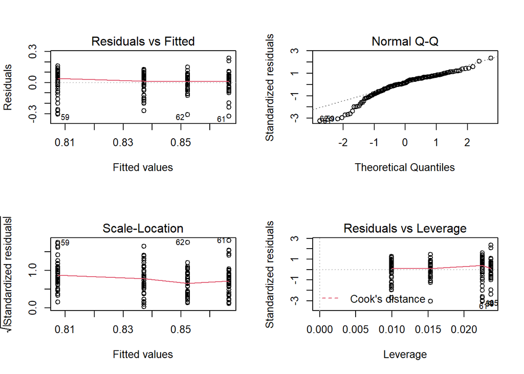

Cuando se analizan las graficas, se observa que los residuales del modelo en la grafica Normal Q-Q se acercan en gran parte a la linea normal, por otro lado cuando se observa los residuales estos tienen un comportamiento agrupado en cuatro valores, no se observa una nube de puntos. Cuando se hace el mismo procedimiento en el set de datos para validación, estos presentan el mismo comportamiento.

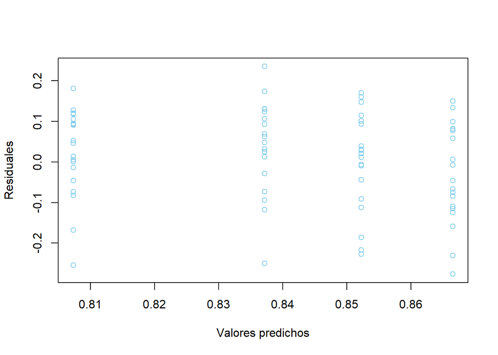

```
## [1] "SME= 0.116962260544177"
```

Debido a los resultados del modelo anterior, se decide explorar otra transformación de los datos, para esto se procede a considerar como variable respuesta la exponencial de la proporción de los costos, buscando un mejor ajuste a un modelo lineal. Por otro lado dado que las dos variable regresoras tienen una alta correlación lineal entre si, se buscó otra variable que tuviera una correlación por encima de 0.5 con la variable respuesta, pero que no estuviese fuertemente correlacionada con las otras dos variables.

#### Modelo lineal con la exponencial de la proporción de los costos

```r
modelo6<-lm(exp(prop_costos) ~ Variacion_PIB_Real+Var_Indice_Real_Precios_Vivienda_Usada, data=datos_entrenamiento)
summary(modelo6)
```

```
##
## Call:
## lm(formula = exp(prop_costos) ~ Variacion_PIB_Real + Var_Indice_Real_Precios_Vivienda_Usada,
##     data = datos_entrenamiento)
##
## Residuals:
##      Min       1Q   Median       3Q      Max
## -0.67760 -0.11273  0.02802  0.14283  0.61377
##
## Coefficients:
##                                        Estimate Std. Error t value Pr(>|t|)
## (Intercept)                             2.16972    0.08135  26.672  < 2e-16 ***
## Variacion_PIB_Real                      6.71982    2.52877   2.657  0.00865 **
## Var_Indice_Real_Precios_Vivienda_Usada  0.13605    2.17885   0.062  0.95029
## ---
## Signif. codes:  0 '***' 0.001 '**' 0.01 '*' 0.05 '.' 0.1 ' ' 1
##
## Residual standard error: 0.2243 on 165 degrees of freedom
## Multiple R-squared:  0.04467,    Adjusted R-squared:  0.03309
## F-statistic: 3.858 on 2 and 165 DF,  p-value: 0.02305
```

```r
summary(exp(datos_entrenamiento["prop_costos"]))
```

```
##   prop_costos
##  Min.   :1.651
##  1st Qu.:2.226
##  Median :2.367
##  Mean   :2.330
##  3rd Qu.:2.476
##  Max.   :3.011
```

**Residuales**

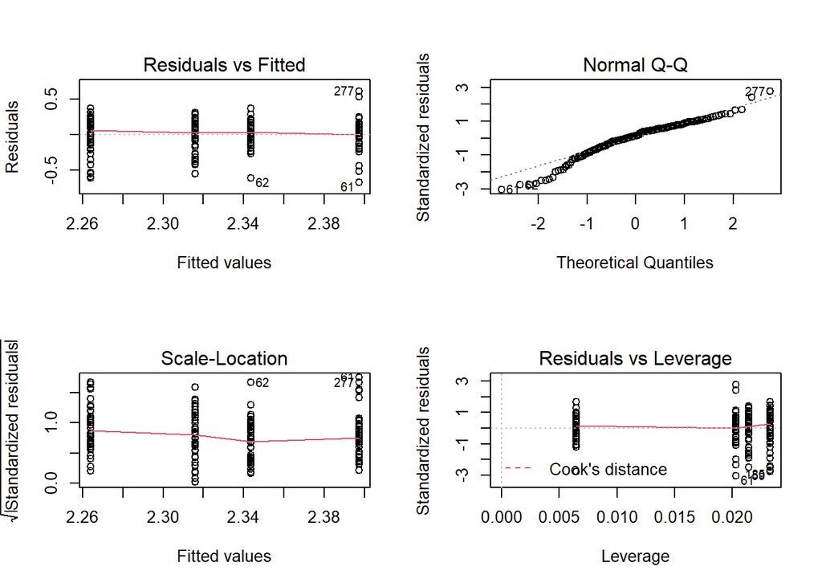

Al analizar la grafica normal Q-Q se observa que se siguen presentando valores distantes a la linea normal, pero aun se continua observando que gran parte de estos se acercan a la linea. Por otro lado los residuales continuan presentando el mismo comportamiento del modelo anterior. Lo anterior tambien sucede con los residuales en los datos de validacion, ya que se observa el comportamiento agrupado.

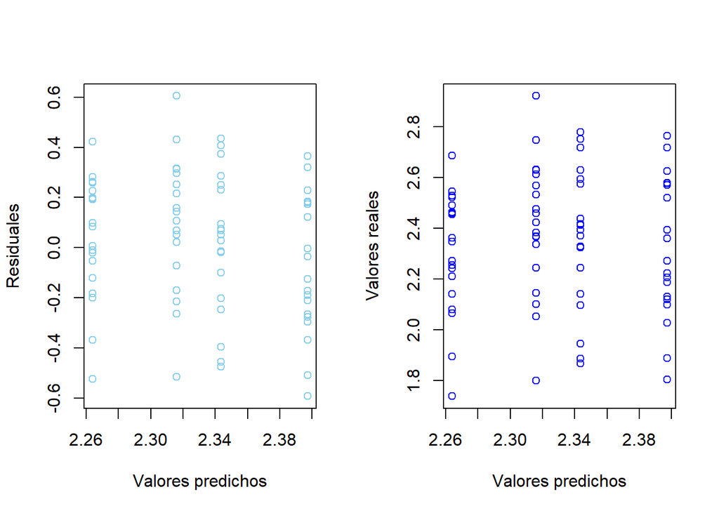

```
## [1] "SME= 0.267453157781861"
```

Tomando esto como precedente, concluimos que un modelo lineal no es suficiente para poder explicar los costos de venta de cada empresa basados en indicadores macroeconomicos, por lo que se considera la opción de usar un modelo de efectos mixtos, el cual nos puede ayudar a carcaterizar cada individuo de la muestra mediante los efectos aleatorios y las pendientes aleatorias asignadas a cada sujeto de la muestra, lo que nos puede llevar a tener un modelo que ajustandoe a nivel de sujeto, tenga una mejor capacidad predictiva y permita modelar los costos de venta.

### Modelos de efectos mixtos

```r
mixtos2 <- lmer(exp_prop_costos ~ Var_Indice_Real_Precios_Vivienda_Usada+  Variacion_PIB_Real+(1+Variacion_PIB_Real|Nit)  , data=datos_entrenamiento)
summary(mixtos2)
```

```
## Linear mixed model fit by REML ['lmerMod']
## Formula:
## exp_prop_costos ~ Var_Indice_Real_Precios_Vivienda_Usada + Variacion_PIB_Real +
##     (1 + Variacion_PIB_Real | Nit)
##    Data: datos_entrenamiento
##
## REML criterion at convergence: -60.7
##
## Scaled residuals:
##     Min      1Q  Median      3Q     Max
## -2.5089 -0.3289  0.1444  0.4743  2.2150
##
## Random effects:
##  Groups   Name               Variance Std.Dev. Corr
##  Nit      (Intercept)         0.05604 0.2367
##           Variacion_PIB_Real 49.44929 7.0320   -0.80
##  Residual                     0.02722 0.1650
## Number of obs: 168, groups:  Nit, 42
##
## Fixed effects:
##                                        Estimate Std. Error t value
## (Intercept)                             2.16972    0.07011  30.947
## Var_Indice_Real_Precios_Vivienda_Usada  0.13605    1.60287   0.085
## Variacion_PIB_Real                      6.71982    2.15361   3.120
##
## Correlation of Fixed Effects:
##             (Intr) V_I_R_
## V_I_R_P_V_U -0.586
## Vrcn_PIB_Rl -0.567 -0.233
```

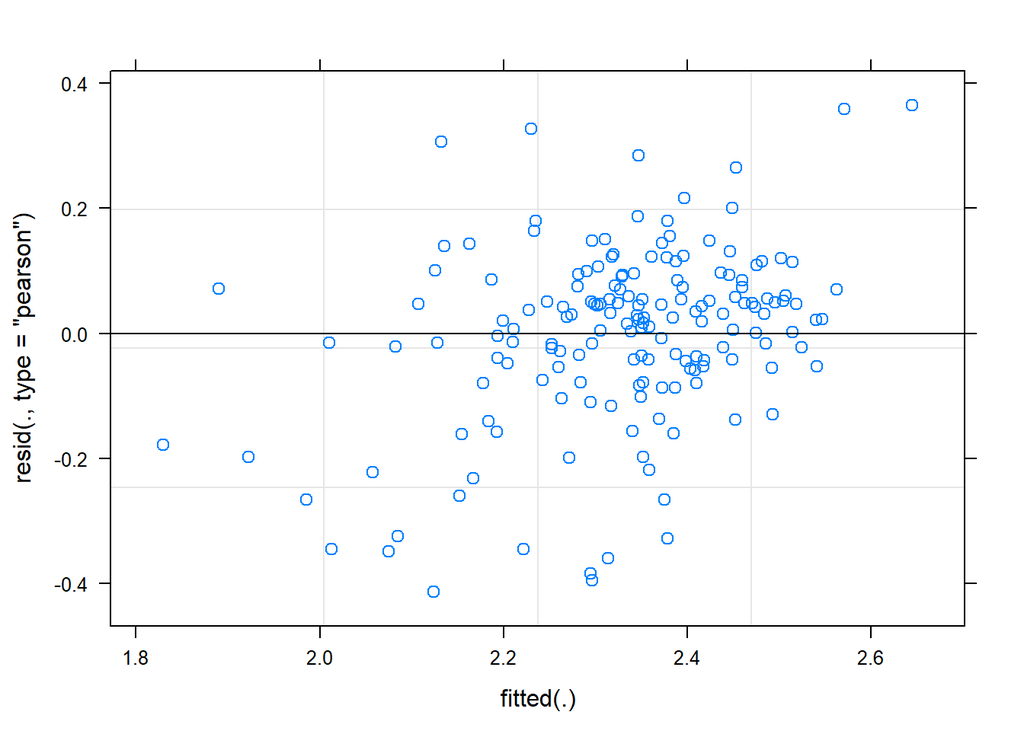

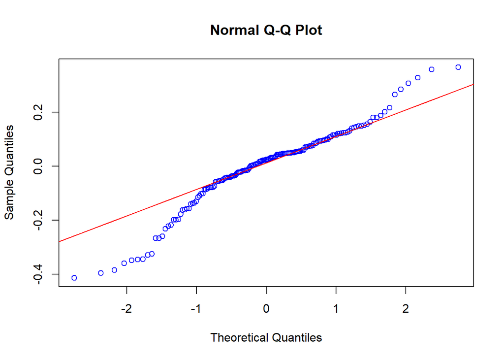

Cuando se analiza la grafica Normal Q-Q se encuentra al igual que los modelos anteriores que aun existen observaciones lejanas a la linea normal, pero se continua encontrando gran parte de estas cercanas a la linea.

```
## [1] "SME= 0.277284084523111"
```

Posteriormente se calculó el SME del modelo en donde se encontró que este es superior al SME del modelo por regresión lineal, al analizar el modelo con datos de validación, se identifica en la grafica que el modelo tiene bajo poder predictivo, ya que se observa casi aleatoriedad en los valores predichos versus los reales

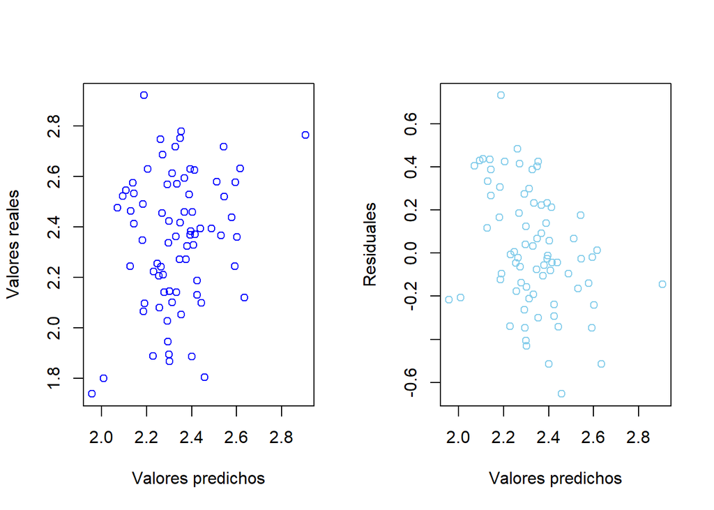

Dado los resultados del modelo anterior se considera tambien el modelo con dos interacciones, buscando reducir la aleatoriedad de la variable respuesta cuando se predice

```r
mixtos3 = lmer(exp_prop_costos ~ Var_Indice_Real_Precios_Vivienda_Usada+  Variacion_PIB_Real+(1+Var_Indice_Real_Precios_Vivienda_Usada|Nit)+(1+Variacion_PIB_Real|Nit)  , data=datos_entrenamiento)
summary(mixtos3)
```

```
## Linear mixed model fit by REML ['lmerMod']
## Formula:
## exp_prop_costos ~ Var_Indice_Real_Precios_Vivienda_Usada + Variacion_PIB_Real +
##     (1 + Var_Indice_Real_Precios_Vivienda_Usada | Nit) + (1 +
##     Variacion_PIB_Real | Nit)
##    Data: datos_entrenamiento
##
## REML criterion at convergence: -67.3
##
## Scaled residuals:
##     Min      1Q  Median      3Q     Max
## -2.0052 -0.3021  0.1288  0.3899  2.3418
##
## Random effects:
##  Groups   Name                                   Variance Std.Dev. Corr
##  Nit      (Intercept)                             0.12552 0.3543
##           Var_Indice_Real_Precios_Vivienda_Usada 71.43466 8.4519   -0.92
##  Nit.1    (Intercept)                             0.05937 0.2437
##           Variacion_PIB_Real                     96.86340 9.8419   -1.00
##  Residual                                         0.01792 0.1339
## Number of obs: 168, groups:  Nit, 42
##
## Fixed effects:
##                                        Estimate Std. Error t value
## (Intercept)                             2.16972    0.08222  26.390
## Var_Indice_Real_Precios_Vivienda_Usada  0.13605    1.84180   0.074
## Variacion_PIB_Real                      6.71982    2.14117   3.138
##
## Correlation of Fixed Effects:
##             (Intr) V_I_R_
## V_I_R_P_V_U -0.717
## Vrcn_PIB_Rl -0.525 -0.134
## convergence code: 0
## unable to evaluate scaled gradient
## Model failed to converge: degenerate  Hessian with 1 negative eigenvalues
```

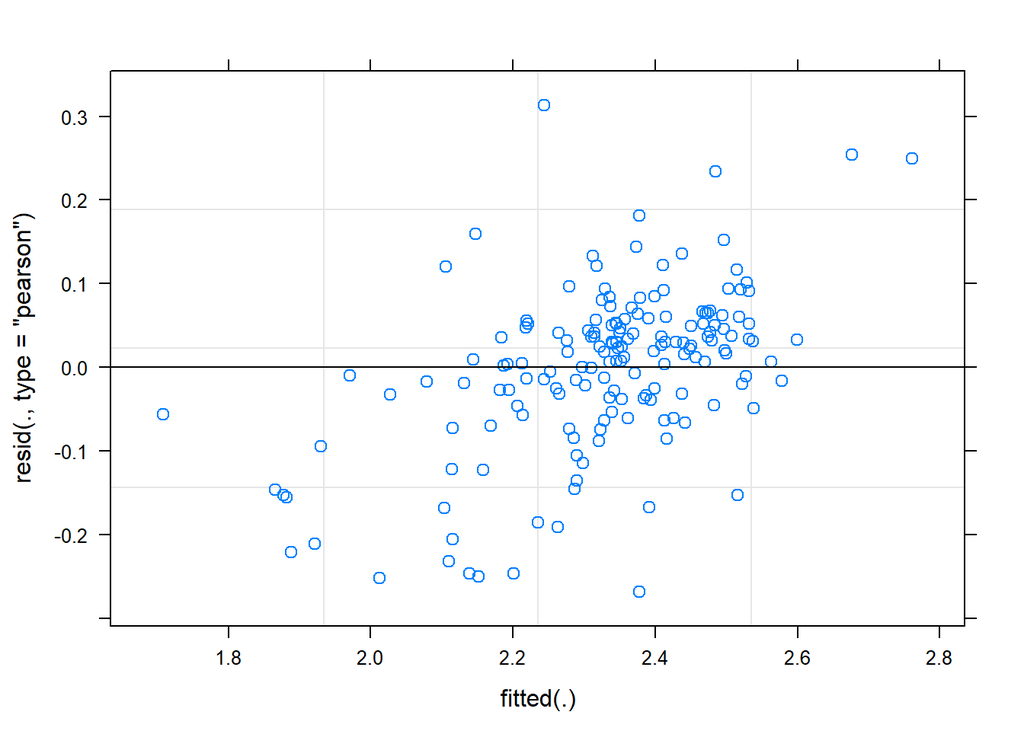

```r
plot(mixtos3)
```

Cuando se analiza los residuales del modelo, y se compara con el modelo de regresión lineal, se encuentra que el rango de los residuales sigue siendo amplio como el modelo de efectos mixtos anterior, pero cuando se grafica los residuales de este, se observa una nube de puntos, por lo que se encuentra una mejoria en los residuales y los valores encontrados con respecto al modelo de regresión lineal.

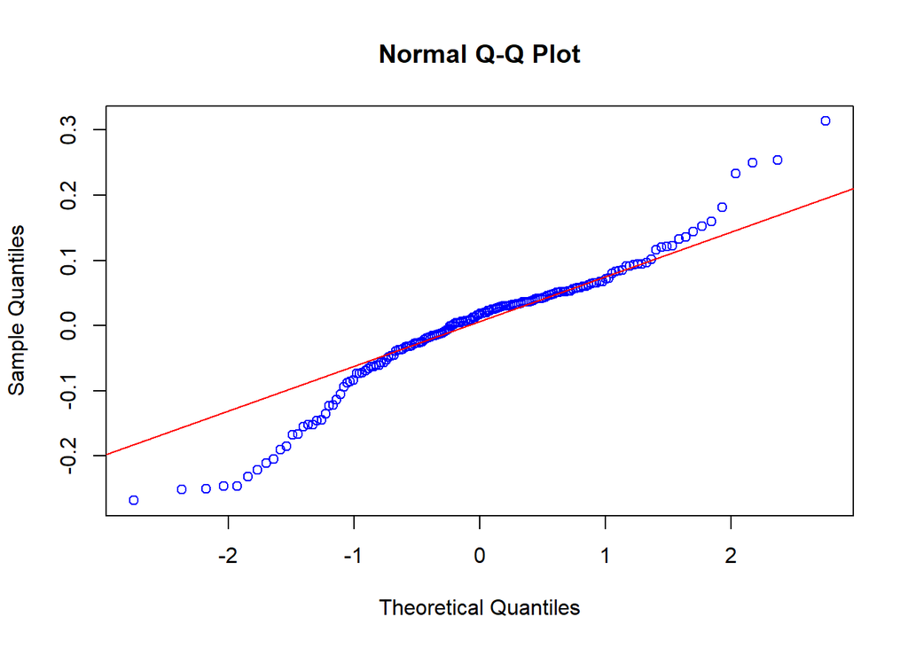

Cuando se analiza la grafica Normal Q-Q se encuentra al igual que los modelos anteriores que aun existen observaciones lejanas a la linea normal, pero se continua encontrando gran parte de estas cercanas a la linea normal, se podria considerar eliminar las empresas cuyos datos se encuentran lejanos a esta linea.

Al analizar el modelo con datos de entrenamiento, se identifica en la grafica que el modelo con estos datos presenta una tendencia lineal, aunque se encuentran datos dispersos

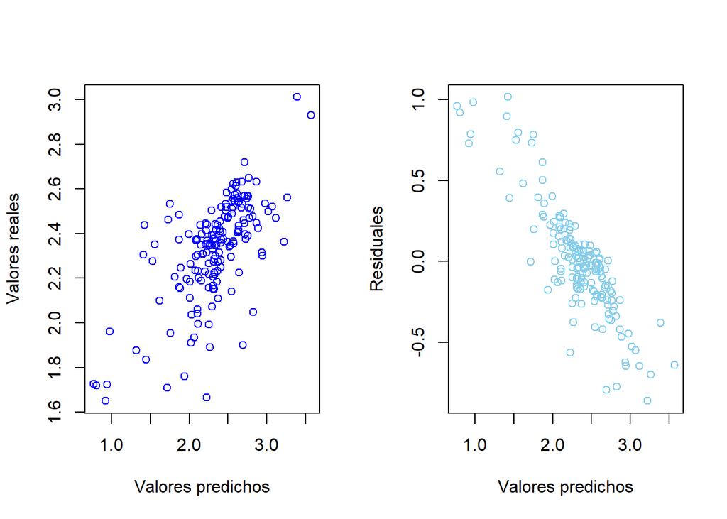

Por ultimo se calculó el SME del modelo con los datos de en donde se encontró que este es superior al SME del modelo por regresión lineal, pero menor al de efectos mixtos anterior, al analizar el modelo con datos de validación, se identifica en la grafica que el modelo tiene bajo poder predictivo, ya que se observa casi aleatoriedad en los valores predichos versus los reales

```
## [1] 0.2699866
```

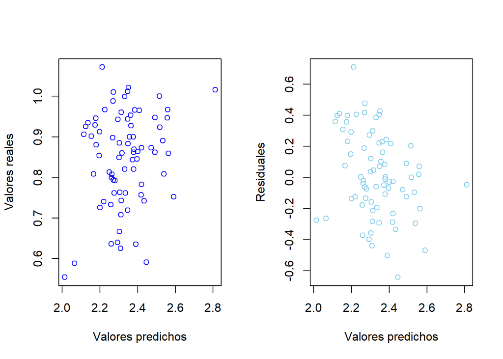

Con la funcion simulate() se buscó simular los efectos aleatorios del modelo de efectos mixtos, los resultados de esta funcion se observan en el cambio de los datos predichos del modelo de regresión lineal, y sus residuales en donde se agrupaban en cuatro valores predichos, pero aun asi se sigue observando dispersion cuando se realiza con el dataset de prueba.

### Analisis

#### Sobre el procesamiento de la información y el analisis exploratorio de datos

Inicialmente de la base de datos construida, realizamos un análisis exploratorio de la base de datos correspondiente al proyecto constituida por información financiera y datos macroeconómicos de fuentes oficiales y veraces.

La base de datos al ser construida sobre 4 años tenía un intervalo de tiempo muy corto, lo que implicó realizar una serie de análisis y transformaciones previamente explicadas con el propósito de poder usar la data y entender como a través de estas transformaciones los modelos podían tener una mejor lectura y por ende lograr una mayor capacidad predictiva sobre nuestra variable respuesta.

Para la variable respuesta también fue necesario entender y transformar con el propósito de eliminar fuentes de variabilidad como los diferentes tamaños de las empresas y las temporalidades de los datos consultados, por esto y con el propósito de incluir las fuentes de variabilidad la variable respuesta elegida fue la proporción de los costos de venta sobre los ingresos de la compañía para así lograr una estandarización de esta medida y poder llevar a cabo un análisis que abarcara las empresas sin tener que incluir otras fuentes de variación en nuestros regresores.

Al hacer un análisis por medio de histogramas de la variable respuesta, se decidió acotarla entre [0.5, 1.2] con el fin de que esta se parezca mas a una distribución normal, por lo que el modelo que se construya será aplicable solo a empresas bajo este criterio.

#### Sobre los modelos de regresión lineal

Para realizar las regresiones lineales inicialmente se decidió usar como regresoras las variables que tenían alta correlación con la variable respuesta pero el modelo no arrojo buenos resultados y solo arrojo betas para tres variables de la regresión, esto se debe a la alta colinealidad que existe entre las diferentes variables macroeconómicas utilizadas, por lo que se decidió probar con modelos lineales simples y ver cual de estas variable se relaciona mejor con la variable respuesta, de allí se obtuvo que “La Variación del PIB” y “La Variación del ICCV”, presentaban betas significativos en sus regresiones lineales simples pero su R cuadrado continuaba siendo muy bajo para predecir la variable respuesta. Se decidió entonces construir un modelo multivariante con estas dos variables, sin alcanzar mejoría ya que sus betas siguen siendo poco significativos y su R cuadrado muy bajo.

Al no obtener buenos resultados con ninguno de los modelos ensayados, se decidió ensayar una transformación exponencial de la variable respuesta, buscando un mejor ajuste a un modelo lineal. Por otro lado dado que las dos variable regresoras tienen una alta correlación lineal entre si, se buscó otra variable que tuviera una correlación por encima de 0.5 con la variable respuesta, pero que no estuviese fuertemente correlacionada con las otras dos variables, en este caso “La Variación del índice Real de Precios de la Vivienda Usada”.

#### Sobre los modelos de fectos mixtos

Al identificar resultados no satisfactorios con modelos lineales se inició el análisis desde la perspectiva de los modelos de efectos mixtos ya que estos modelos tienen un gran poder en la modelación de cada individuo al ser capaces de asignar para cada empresa de la muestra un análisis particular mediante un intercepto y/o una pendiente diferente para cada caso.

En la fase de validación el comportamiento observado no fue tan bueno como se esperaba, pues en las predicciones se pudo observar aleatoriedad entre los datos encontrados y los datos reales, lo que quiere decir que el modelo solo es capaz de predecir sobre los mismos datos que fue modelado, pero ante muestras de testeo, la respuesta no es la misma.

### Conclusiones

Buscando entender la relación entre las variables macroeconomicas y los costos de venta de empresas del sector construcción, el analisis exploratorio de los datos permitió adquirir un mayor conocimiento sobre esta incertidumbre que a veces se presenta en las compañias en el calculo de los presupuestos del año siguiente, y mediante el analisis de correlación se logró identificar algunos comportamientos directamente correlacionados e indirectamente correlacionados, frente a este proceso es importante concluir la importancia de eliminar los efectos de variabilidad de las variables, ya que al no eliminarse o controlarse estos pueden generar resultados sesgados o inconsistentes.

Como primera aproximación al modelamiento, la implementación de modelos lineales en donde se empezó a buscar una relación entre los regresores y la proporción de los costos de venta, los resultados obtenidos en este hace concluir que los modelos lineales no es una buena aproximación para este tipo de problemas pues no permiten establecer relaciones fuertes ni entregar variables significativas dentro del modelo, dado el comportamiento particular de los individuos dentro de la muestra, la estructura de los datos y la baja cantidad de puntos de tiempo analizados, estos modelos ayudaron a entender más la data desde una perspectiva exploratoria más que como una forma de lograr predecir los costos de venta de una empresa en función de las variables macroeconómicas.

El análisis llevado a cabo muestra que para el modelamiento de esta situación un modelo de efectos mixtos tiene un mejor desempeño que un modelo lineal al poder caracterizar cada individuo de forma individual sin embargo el numero reducido de puntos de tiempo evaluados hace que el modelo tenga dificultades a la hora de llevar a cabo predicciones, por lo que se puede concluir que con efectos mixtos se podría llegar a realizar una buena predicción de este comportamiento de costos basado en indicsdores macroeconómicos pero para aumentar el desempeño se debe buscar una base de datos con un rango de tiempo más amplio que permita entender al modelo como los cambios en los indicdores conllevan a un cambio en los costos de venta de las empresas.

Finalmente vale la pena considerar poder evaluar las cifras a nivel mensual o trimestral, que permita tener un mayor panorama del comportamiento que ocurre durante el año y que en ocasiones puede tener mayor explicación a las cifras consolidadas del año, que cuando se analiza con cifras por año, por que en el transcurso del año pueden suceder crecimientos, decrecimientos, y podria verse mas el efecto de estos cambios sobre la proporcion de los costos.

## Tiempos y esfuerzos

#### Recolección y tratamiento de datos (15%):

La recolección de datos de costos e ingresos, selección de el sector la selección de los indicadores a analizar y su unificación; carga de la información a R Studio y análisis preliminar para entender como estaba compuesto el set de datos y cuales criterios de exclusión se iban a considerar al igual que se realizaron procesos de limpieza como eliminación de empresas sin costos o ingresos.

#### Análisis exploratorio (20%):

Posteriormente se hizo un análisis descriptivo de los datos y se propusieron algunas transformaciones tanto de la variable respuesta como de las variables regresoras, finalmente se crearon graficas tipo boxplot e histogramas para entender un poco mas los datos

#### Transformaciones y regresiones lineales (30%):

Identificación de nuevas transformaciones de la variable respuesta con el fin de encontrar aquellas que resultara en un modelo con mayor nivel predictivo, segmentación de la muestra, implementación de modelos de regresión lineal multivariante, definición de aquellas variables más significativas a partir de regresiones lineales simples, analisis de residuales y de valores predichos vs los reales

#### Modelos de efectos mixtos (20%):

Ajuste de los modelos de efectos mixtos, validación de los modelos, e interpretación de los resultados obtenidos

#### Redacción del informe (15%):

Consolidación del informe, analisis de los resultados, interpretación de los modelos, ajuste de las graficas, redacción final.